# Homework 8

Mia Murphy

4/28/2021

### Creating Fake Data Sets To Explore Hypotheses

### Think about an ongoing study in your lab (or a paper you have read in a different class), and decide on a pattern that you might expect in your experiment if a specific hypothesis were true.

### To start simply, assume that the data in each of your treatment groups follow a normal distribution. Specify the sample sizes, means, and variances for each group that would be reasonable if your hypothesis were true. You may need to consult some previous literature and/or an expert in the field to come up with these numbers.

Hypothesis: Wolf pack size is larger when prey species are larger.

Indepedent variable: Prey size

Dependent variable: Pack size

No idea if these numbers are “accurate”, but I read a few journals found in Google Scholar and pack size is larger when prey is bigger, but there are outliers (one study showed a pack of 2 wolves were killing moose regularly, but maybe those moose were young, however it did not differentiate prey weight, making it more difficult to come up with exact numbers for this project).

### Using the methods we have covered in class, write code to create a random data set that has these attributes. Organize these data into a data frame with the appropriate structure.

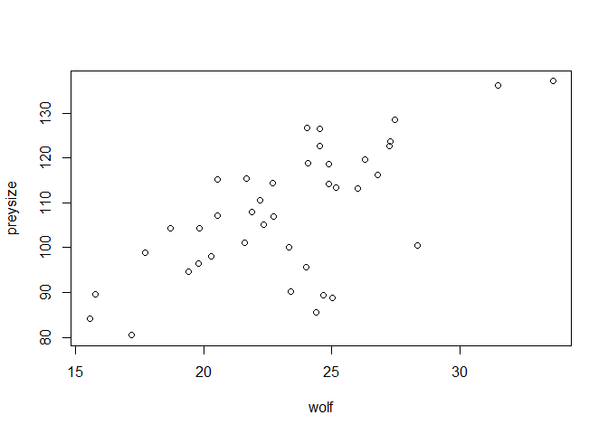

```r
library(ggplot2)

# Create random data
preysize <- rnorm(n=40, mean=100, sd=20) # independent variable
filler <- rnorm(n=40, sd=3)
wolf <- 2 + preysize*.2 + filler # dependent variable

plot(wolf,preysize)
```

### Now write code to analyze the data (probably as an ANOVA or regression analysis, but possibly as a logistic regression or contingency table analysis. Write code to generate a useful graph of the data.

```r
frame1 <- seq_len(40)
```

```r
data1 <- data.frame(frame1, wolf, preysize)
```

```r
head(data1)
```

```
##   frame1     wolf  preysize
## 1      1 31.51202 136.23499
## 2      2 15.55517  84.19469
## 3      3 22.70780 114.42630
## 4      4 26.01375 113.10039
## 5      5 24.52835 122.62589
## 6      6 27.27569 122.67544
```

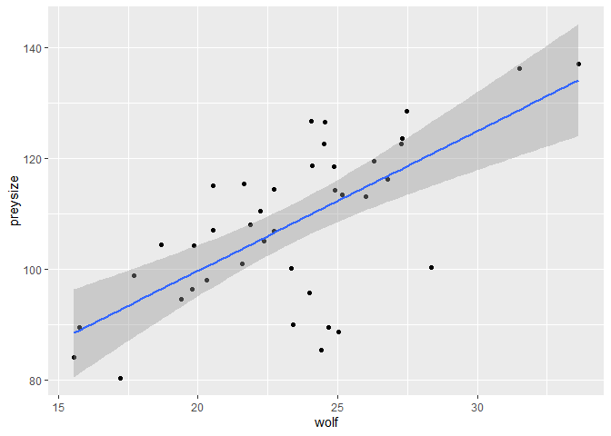

```r
myplot <- ggplot(data=data1, aes(x=wolf, y=preysize)) +
                 geom_jitter() +
                 stat_smooth(method=lm)

print(myplot)
```

### Try running your analysis multiple times to get a feeling for how variable the results are with the same parameters, but different sets of random numbers.

### Now begin adjusting the means of the different groups. Given the sample sizes you have chosen, how small can the differences between the groups be (the “effect size”) for you to still detect a significant pattern (p < 0.05)?

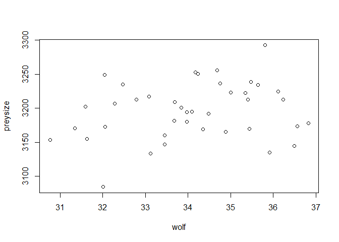

```r
# Create random data
preysize <- rnorm(n=40, mean=3200, sd=40) # independent variable
filler <- rnorm(n=40, sd=2)
wolf <- 2 + preysize*.01 + filler # dependent variable

plot(wolf,preysize)
```

### Alternatively, for the effect sizes you originally hypothesized, what is the minimum sample size you would need in order to detect a statistically significant effect? Again, run the model a few times with the same parameter set to get a feeling for the effect of random variation in the data.

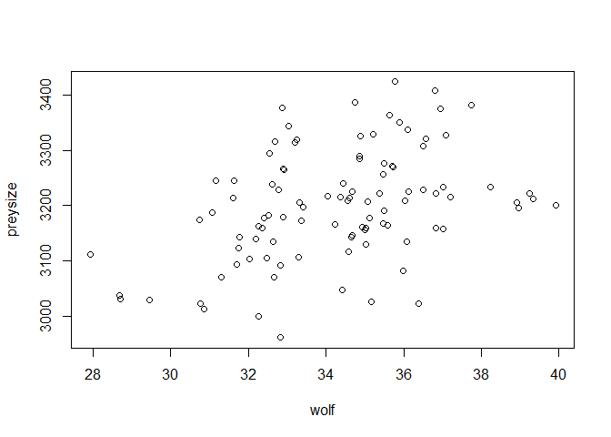

```r
# Create random data
preysize <- rnorm(n=100, mean=3200, sd=100) # independent variable
filler <- rnorm(n=100, sd=2)
wolf <- 2 + preysize*.01 + filler # dependent variable

plot(wolf,preysize)
```

### Write up your results in a markdown file, organized with headers and different code chunks to show your analysis. Be explicit in your explanation and justification for sample sizes, means, and variances.

After analyzing some wolf pack size studies, I tried to mimic the linear pattern associated with prey size and wolf pack size. The filler component is to represent the outliers. There is definitely a linear pattern, as prey size becomes larger, pack sizes become larger. With this random data, the ability to add in outliers is actually very useful, as the studies showed many unexpected outliers (such as the 2 wolves who are highly successful moose hunters) and the numbers here managed to almost mimic the pattern completely. With a little more tinkering and finding precise formulas, I should be able to create a very accurate graph, but this seems like a good start.

I will leave the journals here, in the event that I come back to this and want to create a more accurate data set to get a better understanding of this project.

https://wolf.org/wp-content/uploads/2013/08/355.Differential-wolf-pack-size-persistence-and-the-role-of-risk-when-hunting-dangerous-prey.pdf

https://www.ncbi.nlm.nih.gov/pmc/articles/PMC5193335/

This might be useful for later: https://www.middleprofessor.com/files/applied-biostatistics_bookdown/_book/creating-fake-data.html